# Introduction to R Markdown

May 9, 2018

## Introduction

## What is R Markdown ?

### Markdown

- Markdown is a **simple** language to write documents.
- Markdown **can be converted to many formats**: html, pdf, docx, epub, …

### R Markdown

- R Markdown is a way to **embed R code** within a Markdown document.
- R code can be run and its output part of the final document.

[figure not shown]

Under the hood (from rmarkdown.rstudio.com)

## Why use R Markdown ?

1. Easier to document an analysis.
2. Everything in one place: code, figures, comments.
3. Encourage better analysis, transparency and reproducibility
4. Speed up the "analysis-to-report" time.

### Practical cases

1. Analysis report for you, your PI, or your lab-book/wiki. <sup>*Markdown*</sup>
2. Report to share with collaborators. <sup>*PDF*</sup> <sup>*HTML*</sup>
3. Code associated with a paper. <sup>*Markdown*</sup>
4. Tutorials/workshops. <sup>*Markdown*</sup>
5. Websites/blogs. <sup>*Markdown*</sup>

## How ?

1. Write a Markdown document with your favorite editor/RStudio.
   - Header defines metadata and render parameters.
   - Text using Markdown syntax.
   - R code chunks that will be run.
2. Render the document:
   - In R, run the `render` function from the *rmarkdown* package.
   - In Rstudio, click on `Knit`

## Header

## YAML Header

Defines the metadata of the document and parameters for the compilation.

```yaml
---
title: "Introduction to R Markdown"
subtitle: "MonBUG Meeting"
author: "Jean Monlong"
date: May 9, 2018
output: ioslides_presentation
---
```

## Markdown syntax

## Text syntax

```yaml
# Header 1

## Header 2

### Header 3
```

```yaml
Some text with a **word in bold**, another *in italic* and
a [link](https://rmarkdown.rstudio.com)
```

Some text with a **word in bold**, another *in italic* and a [link](https://rmarkdown.rstudio.com)

## Lists

```yaml
- Bullet item 1
    1. Ordered item 1
    1. Ordered item 2
- Bullet item 2
- Bullet item 3
```

- Bullet item 1
  1. Ordered item 1
  2. Ordered item 2
- Bullet item 2
- Bullet item 3

*Note: 4 spaces to define sub-lists.*

## R code

## R Chunk

````yaml
```{r histtest}
x = rnorm(1000)
hist(x)
```
````

Advice: Name your chunks.

- Used for figure names.
- Helps debugging.

## R Chunk

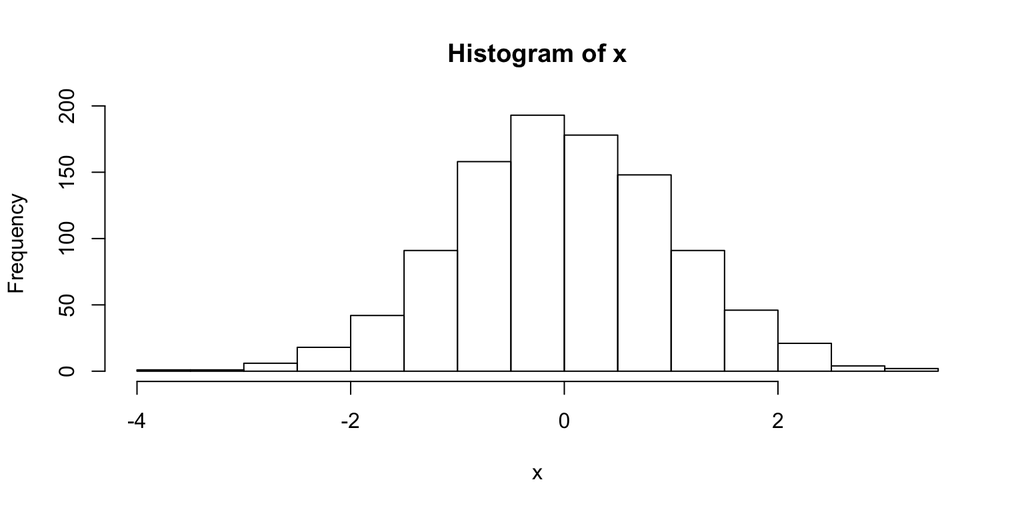

```r
x = rnorm(1000)
hist(x)
```

## Specifying default chunk options

At the beginning of the document. For example "no code" mode:

````yaml
```{r include=FALSE}
knitr::opts_chunk$set(echo=FALSE, message=FALSE,
                      warning=FALSE, fig.width=10)
```
````

Or "code+output" mode:

````yaml
```{r include=FALSE}
knitr::opts_chunk$set(echo=TRUE, message=FALSE,
                      warning=FALSE, fig.width=10, tidy=TRUE)
```
````

## Cache

````yaml
```{r cache=TRUE}
res = reallyLongComputation(x)
hist(res)
```
````

- Use with caution. Especially if it depends on other chunks.
- `dependson` can specify dependency but not very practical.
- Apparently `autodep` tries to understand dependencies.
- Caching manually is safer IMO.

## Tables

## `kable` function

```r
df
```

```
##            time Rmarkdown.knowledge Rmarkdown.usage
## 1 Before MonBUG                3801       0.1123095
## 2  After MonBUG               11543       0.2234982
```

```r
library(knitr)
kable(df)
```

| time | Rmarkdown.knowledge | Rmarkdown.usage |
| --- | --- | --- |
| Before MonBUG | 3801 | 0.1123095 |
| After MonBUG | 11543 | 0.2234982 |

## `kable` and its arguments

```r
kable(df, digits = 2, format.args = list(big.mark = ","),
    col.names = c("Time", "RMarkdown knowledge",
        "Rmarkdown usage"))
```

| Time | RMarkdown knowledge | Rmarkdown usage |
| --- | --- | --- |
| Before MonBUG | 3,801 | 0.11 |
| After MonBUG | 11,543 | 0.22 |

## Resize wide tables for Beamer slides

````yaml
```{r, include=FALSE}
knitr::knit_hooks$set(resize = function(before, options, envir) {
    if (before) {
      return('\\resizebox{\\textwidth}{!}{')
    } else {
      return('}')
    }
})
```

## Wide table

```{r, resize=TRUE}
knitr::kable(df, format='latex')
```
````

## Output formats

## Markdown

```yaml
---
output: md_document
---
```

For GitHub/Bitbucket pages or wikis.

```yaml
---
output:
  md_document:
    variant: markdown_github
---
```

## HTML

```yaml
---
title: "Your title"
output:
  html_document:
    toc: true
---
```

Customizable themes and cool features:

- Table of Contents (`toc`).
- Floating Table of Contents (`toc_float`).
- Fold code chunks (`code_folding`).
- Tabs.

## Beamer presentation (PDF)

```yaml
---
title: "Introduction to R Markdown"
subtitle: "MonBUG Meeting"
author: "Jean Monlong"
date: May 9, 2018
output: beamer_presentation
---
```

Trick: use PNG image types to reduce PDF size (sometimes).

```yaml
output:
  beamer_presentation:
    dev: png
```

## Beamer presentation (PDF)

Remove navigation bar and add page numbers

```yaml
---
output:
  beamer_presentation:
    includes:
      in_header: header.tex
---
```

And in `header.tex`:

```latex
\setbeamertemplate{navigation symbols}{}
\setbeamertemplate{footline}[page number]
```

## Sharing documents

- Single files
  - PDF
  - HTML have images embedded.
- On GitHub as Markdown files
  - `.md` file and `_files` folder (with images).
- On GitHub as HTML files
  - Name the file `index.html` and switch on GitHub Pages.
  - Use [rawgit.com](https://rawgit.com/).
- On [RPubs](https://rpubs.com/) ("Publish" button in RStudio).

## Going further

## Documentation

- [R Markdown](https://rmarkdown.rstudio.com/)
- [Chunk options from knitr's website](https://yihui.name/knitr/options/)
- [R Markdown Cheatsheet](https://www.rstudio.com/wp-content/uploads/2016/03/rmarkdown-cheatsheet-2.0.pdf) (2 pages).
- [R Markdown Reference Guide](https://www.rstudio.com/wp-content/uploads/2015/03/rmarkdown-reference.pdf) (5 pages).

## Going further

- Bibliography from `.bib` files.
- Websites with the [`blogdown` package](https://bookdown.org/yihui/blogdown/).
- Dashboards, e.g. [flexdashboard](https://rmarkdown.rstudio.com/flexdashboard/index.html)
- [Interactive notebooks](https://rmarkdown.rstudio.com/r_notebooks.html).
- Interactive graphs in HTML documents ([example](http://timelyportfolio.github.io/rCharts_nyt_home_price/)).